# TRIPOD - 10x Genomics PBMC 10k

Yuchao Jiang, Yuriko Harigaya, Nancy R. Zhang

2023-01-06

# 1 Introduction

TRIPOD is a statistical framework for detecting three-way regulatory relationships between a *cis*-regulatory chromosomal region, a transcription factor (TF), and a target gene, which we call a “trio,” using single-cell ATAC/RNA multiomic data. This approach can complement commonly used methods based on pair-wise associations between two of the three elements (e.g., a TF and a target gene). The main functionality of this package is:

- Infers trio regulatory relationships using robust nonparametric models

The package is augmented by the following two related functionalities:

- Builds RNA prediction models from ATAC-seq data
- Identifies cell-types in which a trio regulatory relationship is active by estimating the influence of a data point in linear regression

Here, we demonstrate the use of TRIPOD to study epigenetic control of gene expression using sigle-cell multiomic data, which is publicly available from [10x Genomics](https://support.10xgenomics.com/single-cell-multiome-atac-gex/datasets). The data was generated in 11909 cells of human peripheral blood mononuclear cells (PBMCs) and contains ATAC-seq and RNA-seq read counts for 108377 ATAC peaks and 36601 gene regions, respectively. Note that multiomic data generated via other protocols can be analyzed using this package.

# 2 Key features of the TRIPOD method

In the TRIPOD method, for a given gene, $g$, we consider a set of ATAC peaks near the transcription start site (TSS), which are candidate *cis*-regulatory elements. In most cases, we include peaks 100 to 200 Kb up and downstream from TSS. We also consider RNA expression levels of a set of TFs whose binding motifs are present in any of the peaks.

For a given trio consisting of the gene $g$, the peak $t$, and the TF $j$, TRIPOD characterizes the target gene expression (denoted as $Y_g$) as a function of the chromatin accessibility in the peak region (denoted as $X_t$) and the TF (denoted as $Y_j$) expression. The $X_t$ variables are extracted from the ATAC-seq data, whereas the $Y_g$ and $Y_j$ variables are extracted from the RNA-seq data.

Additionally, TRIPOD has the following features.

- Use a matching-based, nonparametric approach to account for potentially nonlinear relationships between the variables
- Use a two-level testing framework to allow for multiple levels of stringency
- Construct metacells by aggregating information across similar cells to mitigate the issues of the sparsity and noisiness of single cell data

# 3 Required packages

The TRIPOD package is available from [GitHub](https://github.com/yuchaojiang/TRIPOD).

```r
if (!requireNamespace("devtools", quietly = TRUE)) install.packages("devtools")
devtools::install_github("yuchaojiang/TRIPOD/package")
```

```r
library(TRIPOD)
```

Additionally, the following packages are required to run this vignette.

```r
library(Seurat)
library(Signac)
library(GenomicRanges)
library(dplyr)
library(ggplot2)
library(EnsDb.Hsapiens.v86)
library(BSgenome.Hsapiens.UCSC.hg38)
library(GenomeInfoDb)
library(patchwork)
library(BiocParallel)
library(dendextend)
```

# 4 Detecting candidate trio regulatory relationships

In this section, we demonstrate how to screen for trio regulatory relationships using data objects that have been preprocessed from the multiomics data and included in the TRIPOD package. The preprocessing is described in [the accompanying preprocessing vignette](http://htmlpreview.github.io/?https://github.com/yuchaojiang/TRIPOD/blob/main/vignettes/preprocessing_pbmc.html).

The following code loads objects that are necessary for analyzing the PBMC data.

```r
load('pbmc.transcripts.gr.rda')
load('pbmc.peaks.gr.rda')
load('pbmc.motifxTF.rda')
load('pbmc.peakxmotif.rda')
load('pbmc.metacell.rna.rda')
load('pbmc.metacell.peak.rda')
load('pbmc.metacell.celltype.rda')
load('pbmc.metacell.celltype.col.rda')
```

## 4.1 Fitting models

Although we typically run model fitting for over 1000 target genes, in this vignette, we fit models for two examples genes, *CCR7* and *GNLY* for demonstration purposes.

```r
genes <- c("CCR7", "GNLY")
```

We set the size of the window around transcription start sites (TSS) to 100 kb. For a given gene, ATAC peaks within the windows are considered as possible *cis*-regulatory regions.

```r
ext.upstream <- ext.downstream <- 1e5
```

We first invoke the `getXYMatrices()` function. For a given gene, the function returns a list containing a set of $Y_g$, $X_t$, and $Y_j$, which we call a `xymats` list. Here, we obtain a list of `xymats` objects for the two genes.

```r
xymats.list <- bplapply(
  genes,
  getXYMatrices,
  ext.upstream = ext.upstream,
  transcripts.gr = pbmc.transcripts.gr,
  peaks.gr = pbmc.peaks.gr,
  metacell.rna = pbmc.metacell.rna,
  metacell.peak = pbmc.metacell.peak,
  peakxmotif = pbmc.peakxmotif,
  motifxTF = pbmc.motifxTF,
  metacell.celltype = pbmc.metacell.celltype,
  metacell.celltype.col = pbmc.metacell.celltype.col
)
names(xymats.list) <- genes
```

We then run TRIPOD using the following code. Note that TRIPOD can be run matching either chromatin accessibility, $X_t$, or TF expression, $Y_j$. In either case, two tests with different stringency are performed (level 1 and level 2). See [our manuscript](https://www.biorxiv.org/content/10.1101/2021.09.22.461437v1) for details.

```r
# run TRIPOD matching Xt
xymats.tripod.Xt.list <- bplapply(
    xymats.list,
    fitModel,
    model.name = "TRIPOD",
    match.by = "Xt"
)
names(xymats.tripod.Xt.list) <- genes
# run TRIPOD matching Yj
xymats.tripod.Yj.list <- bplapply(
    xymats.list,
    fitModel,
    model.name = "TRIPOD",
    match.by = "Yj"
)
names(xymats.tripod.Yj.list) <- genes
```

## 4.2 Getting lists of hits

Next, we select hits by Benjamini-Hochberg (BH) method with a certain FDR threshold. We typically use a threshold of 0.01 and focus on hits with significantly positive coefficients.

```r
# set FDR < 0.01
fdr.thresh <- 0.01

# focus on positive sign
sign <- "positive"
```

The `getTrios()` function returns a data frame with columns containing the target gene name, peak number, TF number, peak name, TF name, estimates of the coefficient, nominal $p$-value, and BH-adjusted $p$-value. Here, for brevity, we only show the code for TRIPOD level 1 and level 2 matching $X_t$.

```r
# TRIPOD level 1 matching Xt
xymats.tX1.pos.df <- getTrios(
    xymats.list = xymats.tripod.Xt.list,
    fdr.thresh = fdr.thresh,
    sign = sign,
  model.name = "TRIPOD",
    level = 1
)
head(xymats.tX1.pos.df[order(xymats.tX1.pos.df$adj), ])
```

```
#>    gene peak_num TF_num                    peak    TF      coef         pval
#> 19 CCR7       27     93 chr17-40617592-40618016  ETS1 0.9032967 0.000000e+00
#> 20 CCR7        4     96 chr17-40479400-40483190  LEF1 0.9398396 0.000000e+00
#> 59 CCR7        4    333 chr17-40479400-40483190  TCF7 0.9137701 0.000000e+00
#> 68 GNLY       16     24  chr2-85669491-85669988  ESR2 0.8725275 0.000000e+00
#> 74 GNLY       36     64  chr2-85753028-85755916 TBX21 0.8136812 8.560269e-09
#> 76 GNLY       36    118  chr2-85753028-85755916 EOMES 0.8153693 7.527622e-09
#>             adj
#> 19 0.000000e+00
#> 20 0.000000e+00
#> 59 0.000000e+00
#> 68 0.000000e+00
#> 74 5.992188e-06
#> 76 7.904003e-06
```

```r
# TRIPOD level 2 matching Xt
xymats.tX2.pos.df <- getTrios(
    xymats.list = xymats.tripod.Xt.list,
    fdr.thresh = fdr.thresh,
    sign = sign,
  model.name = "TRIPOD",
    level = 2
)
head(xymats.tX2.pos.df[order(xymats.tX2.pos.df$adj), ])
```

```
#>    gene peak_num TF_num                   peak     TF      coef         pval
#> 8  GNLY       23     64 chr2-85693711-85699520  TBX21 0.4225060 1.715285e-18
#> 5  GNLY       25     24 chr2-85704208-85707856   ESR2 0.5082302 2.516000e-12
#> 10 GNLY       25    118 chr2-85704208-85707856  EOMES 0.6044532 3.924161e-10
#> 11 GNLY       21    119 chr2-85684653-85685264    MGA 2.6452547 1.796505e-09
#> 13 GNLY       25    135 chr2-85704208-85707856   XBP1 0.2343151 4.087960e-09
#> 6  GNLY       25     34 chr2-85704208-85707856 NFATC3 0.1460374 1.230052e-08
#>             adj
#> 8  3.097804e-15
#> 5  1.514632e-09
#> 10 1.771759e-07
#> 11 6.488977e-07
#> 13 1.230476e-06
#> 6  2.468305e-06
```

The hits from the four variations of TRIPOD (level 1 test matching $X_t$, level 2 test matching $X_t$, level 1 test matching $Y_j$, level 2 test matching $Y_j$) can be used separately in downstream analyses. Alternatively or additionally, the union set can be used.

## 4.3 Visualizaing the results

We recommend visually inspecting the trio hits by generating scatter plots. In this section, we demonstrate data visualization focusing on the putative regulation of the *GNLY* gene by the TBX21 TF via the peak chr2−85693711−85699520.

```r
gene.name <- "GNLY"
TF.name <- "TBX21"
peak.name <- "chr2-85693711-85699520"
```

First, we extract a `xymats` object for the target gene *GNLY* from the `xymats.list` we have created.

```r
xymats <- xymats.list[[gene.name]]
```

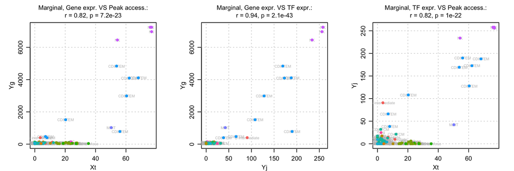

```r
par(pty = "s", mgp = c(2, 0.8, 0), mar = c(3, 3, 3, 1), mfrow = c(1, 3))
plotGenePeakTFScatter(
    xymats = xymats, peak.name = peak.name, TF.name = TF.name,
  to.plot = "marginal.Yg.Xt",
    cap.at.quantile = 0.02,
    metacell.celltype = pbmc.metacell.celltype,
    metacell.celltype.col = pbmc.metacell.celltype.col
)

plotGenePeakTFScatter(
    xymats = xymats, peak.name = peak.name, TF.name = TF.name,
  to.plot = "marginal.Yg.Yj",
    cap.at.quantile = 0.02,
    metacell.celltype = pbmc.metacell.celltype,
    metacell.celltype.col = pbmc.metacell.celltype.col
)

plotGenePeakTFScatter(
    xymats = xymats, peak.name = peak.name, TF.name = TF.name,
  to.plot = "marginal.Yj.Xt",
    cap.at.quantile = 0.02,
    metacell.celltype = pbmc.metacell.celltype,
    metacell.celltype.col = pbmc.metacell.celltype.col
)
```

The following code visualizes pairs of meta-cells, which are used in the TRIPOD models.

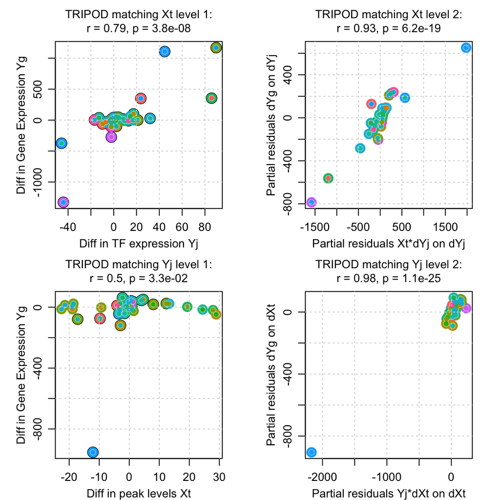

```r
par(pty = "s", mgp = c(2, 0.8, 0), mar = c(3, 3, 3, 1), mfrow = c(2, 2))
plotGenePeakTFScatter(
    xymats = xymats, peak.name = peak.name, TF.name = TF.name,
  to.plot = "TRIPOD",
    match.by = "Xt",
    level = 1,
    cap.at.quantile = 0.02,
    metacell.celltype = pbmc.metacell.celltype,
    metacell.celltype.col = pbmc.metacell.celltype.col
)

plotGenePeakTFScatter(
    xymats = xymats, peak.name = peak.name, TF.name = TF.name,
  to.plot = "TRIPOD",
    match.by = "Xt",
    level = 2,
    cap.at.quantile = 0.02,
    metacell.celltype = pbmc.metacell.celltype,
    metacell.celltype.col = pbmc.metacell.celltype.col
)

plotGenePeakTFScatter(
    xymats = xymats, peak.name = peak.name, TF.name = TF.name,
  to.plot = "TRIPOD",
    match.by = "Yj",
    level = 1,
    cap.at.quantile = 0.02,
    metacell.celltype = pbmc.metacell.celltype,
    metacell.celltype.col = pbmc.metacell.celltype.col
)

plotGenePeakTFScatter(
    xymats = xymats, peak.name = peak.name, TF.name = TF.name,
  to.plot = "TRIPOD",
    match.by = "Yj",
    level = 2,
    cap.at.quantile = 0.02,
    metacell.celltype = pbmc.metacell.celltype,
    metacell.celltype.col = pbmc.metacell.celltype.col
)
```

Additional visualization can provide insights into the cell-type specificity of the regulation. For this purpose, we first load the Seurat object, which can be generated through a process described in [the preprocessing vignette](http://htmlpreview.github.io/?https://github.com/yuchaojiang/TRIPOD/blob/main/vignettes/preprocessing_pbmc.html). Alternatively, the processed Seurat object can be downloaded [here](https://www.dropbox.com/s/o6n2u2qbvvqe86g/pbmc.rds?dl=0).

```r
file <- "pbmc.rds"
path <- file.path("path/to/your/dir", file)
pbmc <- readRDS(path); rm(path)
```

The following code visualizes RNA expression of the target gene, chromatin accessibility of the ATAC peak region, and RNA expression of the gene encoding the TF in UMAP, violin, and dot plots.

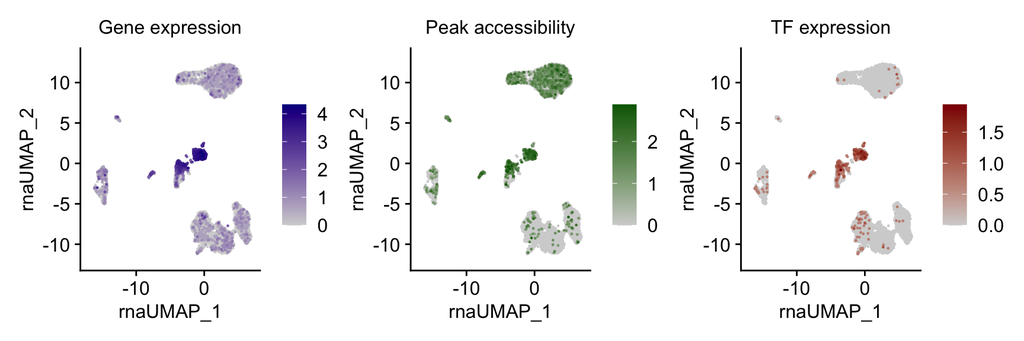

```r
plotGenePeakTFUMAP(object = pbmc, gene.name = gene.name,
    peak.name = peak.name, TF.name = TF.name,
    reduction = "umap.rna", order = TRUE,
    size.title = 12, size.axis = 12)
```

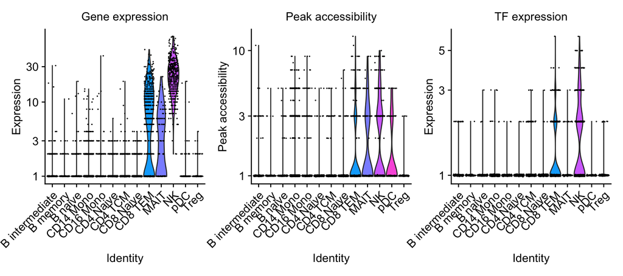

```r
plotGenePeakTFVln(object = pbmc, gene.name = gene.name,
    peak.name = peak.name, TF.name = TF.name,
    group.by = "celltype", size.title = 12, size.axis = 12)
```

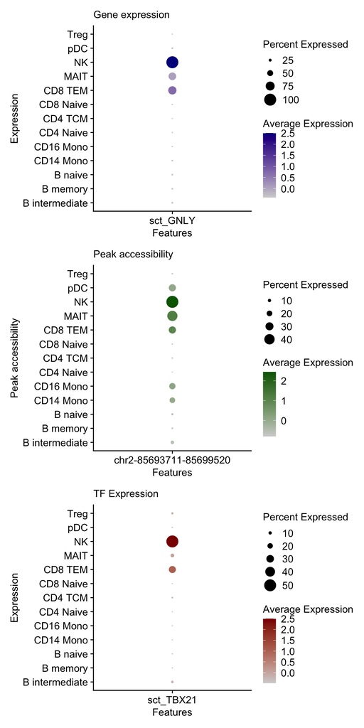

```r
plotGenePeakTFDot(object = pbmc, gene.name = gene.name,
    peak.name = peak.name, TF.name = TF.name,
    group.by = "celltype",
    size.title = 12, size.axis = 12, size.legend = 12, ncol = 1)
```

# 5 Predicting RNA expression using ATAC-seq data

The `performRNAPrediction()` function builds predictive models of gene expression on chromatin accessibility of the vicinity region. While this framework is not intended for genuinely prediction purposes since scRNA-seq data are required as predictors, it allows for examining whether TF RNA expression information improves the prediction of the target gene expression in a given dataset.

## 5.1 Fitting models

We demonstrate the predictive modeling focusing on the *CCR7* gene. We utilize the `xymats` object we have created with a window size of 100 Kb (see Section 4).

```r
gene.name <- "CCR7"
xymats <- xymats.list[[gene.name]]
```

The following code fits a LASSO model with products of chromatin accessibility and TF expression as predictors.

```r
xymats.peak.tf.lasso <- performRNAPrediction(xymats = xymats, model.name = "peak.TF.LASSO",
    cap.at.quantile = 0.02, seed = NULL)
```

The model can be evaluated by Pearson correlation between the observed gene expression and leave-one-out prediction.

```r
xymats.peak.tf.lasso$cor
```

```
#> [1] 0.972
```

For comparison, we build the gene activity model.

```r
xymats.gene.activity <- performRNAPrediction(xymats = xymats, model.name = "gene.activity",
    cap.at.quantile = 0.02, seed = NULL)
xymats.gene.activity$cor
```

```
#> [1] 0.7996219
```

We also preform LASSO on chromatin accessibility.

```r
xymats.peak.lasso <- performRNAPrediction(xymats = xymats, model.name = "peak.LASSO",
    cap.at.quantile = 0.02, seed = NULL)
xymats.peak.lasso$cor
```

```
#> [1] 0.9552029
```

## 5.2 Visualizaing the results

The models can be investigated by visualization as follows.

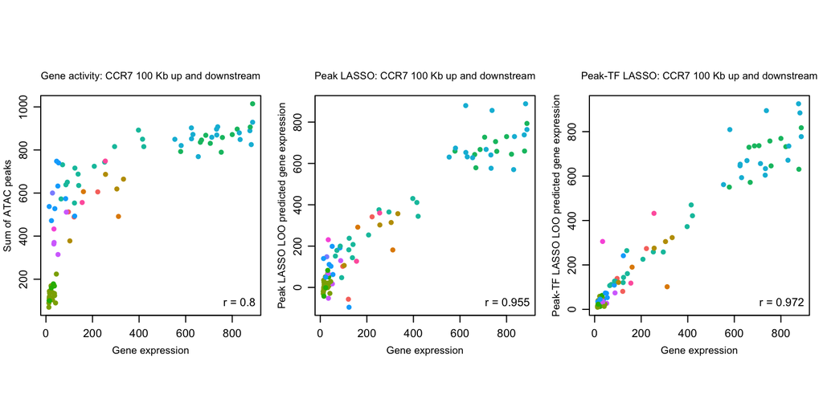

```r
par(pty = "s", mgp = c(2, 0.8, 0), mar = c(3, 3, 3, 1), mfrow = c(1, 3))
plotRNAPrediction(
    xymats.gene.activity, metacell.celltype = pbmc.metacell.celltype,
    metacell.celltype.col = pbmc.metacell.celltype.col, cex.main = 0.9, cex.lab = 0.9)

plotRNAPrediction(
    xymats.peak.lasso, metacell.celltype = pbmc.metacell.celltype,
    metacell.celltype.col = pbmc.metacell.celltype.col, cex.main = 0.9, cex.lab = 0.9)

plotRNAPrediction(
    xymats.peak.tf.lasso, metacell.celltype = pbmc.metacell.celltype,
    metacell.celltype.col = pbmc.metacell.celltype.col, cex.main = 0.9, cex.lab = 0.9)
```

# 6 Identifying putative cell-type-specific trio regulatory relationships

In this section, we demonstrate the functionality of the TRIPOD package to infer cell types in which a trio regulatory relationship may be active by estimating the influence of a data point in models. In the current version of the package, we only implement this framework with a linear interaction model (see [the vignette for mouse embryonic brain data] (https://htmlpreview.github.io/?https://github.com/yuchaojiang/TRIPOD/blob/main/vignettes/TRIPOD_e18.html) or [our manuscript](https://www.biorxiv.org/content/10.1101/2021.09.22.461437v1)) due to the large computational burdens of performing the sampling procedure on the nonparametric models.

## 6.1 Preparation

We focus on the regulation of the *GNLY* gene by the TBX21 TF via the peak chr2-85693711-85699520, which gives a significantly positive coefficient of the interaction term (see below).

```r
gene.name <- "GNLY"
TF.name <- "TBX21"
peak.name <- "chr2-85693711-85699520"
```

We first obtain a `xymats` object.

```r
ext.upstream <- 1e5
xymats <- getXYMatrices(gene.name = gene.name, ext.upstream = ext.upstream,
  transcripts.gr = pbmc.transcripts.gr, peaks.gr = pbmc.peaks.gr,
  metacell.rna = pbmc.metacell.rna, metacell.peak = pbmc.metacell.peak,
  peakxmotif = pbmc.peakxmotif, motifxTF = pbmc.motifxTF,
  metacell.celltype = pbmc.metacell.celltype, metacell.celltype.col = pbmc.metacell.celltype.col
)
```

We then obtain indices for the TF and the peak.

```r
peak.num <- which(rownames(xymats$peakxmotif.g) == peak.name)
TF.num <- which(xymats$TF.g == TF.name)
```

Using the indices, we obtain the $Y_g$, $X_t$, and $Y_j$ vectors.

```r
Yg <- xymats$Yg
Xt <- xymats$Xt[, peak.num]
Yj <- xymats$Yj[, TF.num]
```

We then cap the values to eliminate outliers using `capValues()`.

```r
cap.at.quantile <- 0.02
Yg <- capValues(Yg, cap.at.quantile = cap.at.quantile)
Xt <- capValues(Xt, cap.at.quantile = cap.at.quantile)
Yj <- capValues(Yj, cap.at.quantile = cap.at.quantile)
```

We fit the linear interaction model to verify that the coefficient for the interaction term (`gamma.i`) is significantly positive.

```r
xymats.example <- fitModel(xymats = xymats, model.name = "interaction")
c(xymats.example$gamma.i[peak.num, TF.num], xymats.example$pval.gamma.i[peak.num, TF.num])
```

```
#> [1] 2.952231e-01 1.464632e-09
```

## 6.2 Analyzing the influence of deleting one metacell at a time

To examine the influence of deleting one metacell, we compute Cook’s D using the `getCooksD()` function. Please refer to the vignettes of the `oslrr` package [here](https://cran.r-project.org/web/packages/olsrr/vignettes/intro.html) and [here](https://cran.r-project.org/web/packages/olsrr/vignettes/influence_measures.html) for details.

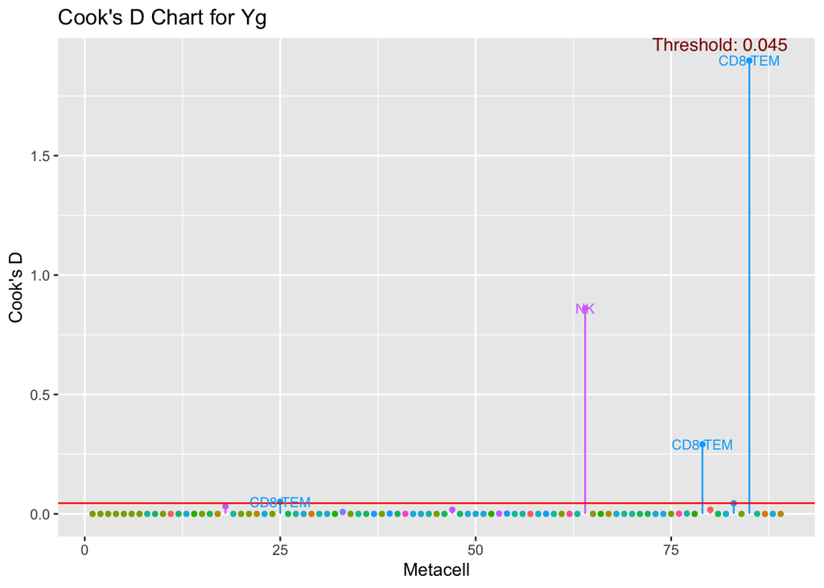

```r
d.list <- getCooksD(Yg, Xt, Yj, pbmc.metacell.celltype)
p <- plotCooksD(d.list, pbmc.metacell.celltype.col)
p
```

The following code computes DFFIT.

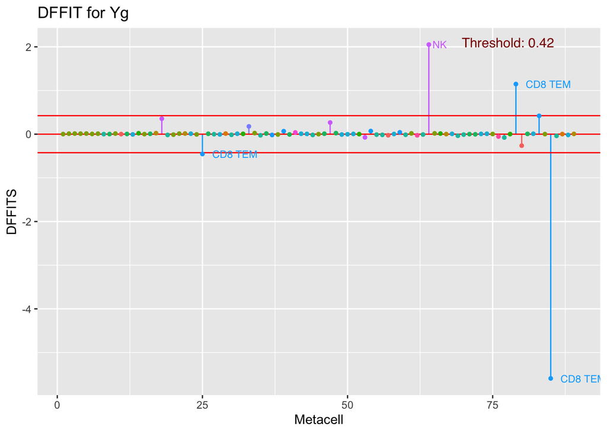

```r
d.list <- getDFFIT(Yg, Xt, Yj, pbmc.metacell.celltype)
p <- plotDFFIT(d.list, pbmc.metacell.celltype.col)
p
```

## 6.3 Analyzing the influence of deleting metacells of a given cell type at a time

To infer the cell type in which the trio regulatory relationship may be active, we examine the influence of deleting metacells of each of the cell types simultaneously using the `deleteCelltype()` function.

```r
delta.coeff.pval <- deleteCellType(Yg = Yg, Xt = Xt, Yj = Yj,
                                   metacell.celltype = pbmc.metacell.celltype)
```

The following code generates a plot of the $p$-values.

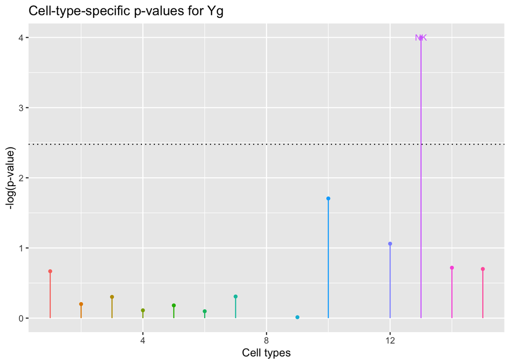

```r
ordered.celltype <- levels(pbmc$celltype)
p <- plotInfluenceForCellType(delta.coeff.pval = delta.coeff.pval,
                              threshold = 0.05/length(ordered.celltype),
                              metacell.celltype = pbmc.metacell.celltype,
                              metacell.celltype.col = pbmc.metacell.celltype.col,
                              ordered.celltype = ordered.celltype)
p
```

The above result implies that the regulation of the *GNLY* gene by the TBX21 TF via the peak chr2-85693711-85699520 may occur in the NK cells.

## 6.4 Analyzing the influence of deleting metacells of related cell types

The TRIPOD package also provides a functionality to analyze the influence of deleting metacells of related cell types simultaneously. The first step in this process is to obtain a tree structure of the cell types by hierarchical clustering. In this analysis, we use the RNA modality.

```r
dend <- getDendrogram(metacell.matrix = pbmc.metacell.rna,
    metacell.celltype = pbmc.metacell.celltype)
```

We then obtain sampling $p$-values for subtrees in the tree structure.

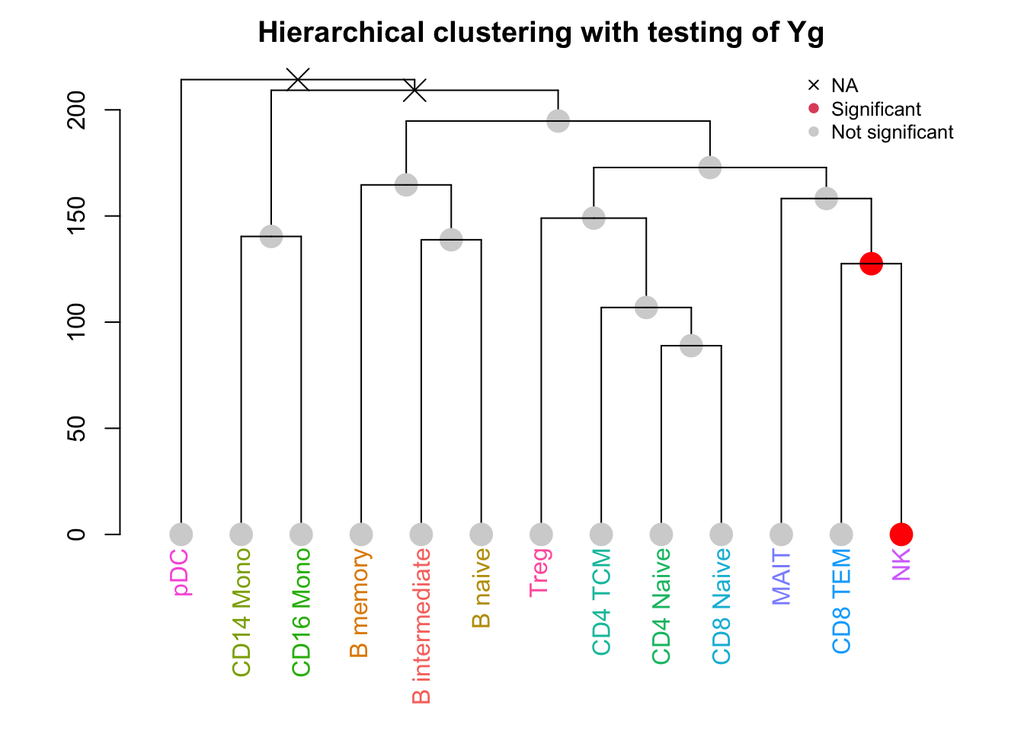

```r
delta.coeff.pval <- deleteBranch(Yg = Yg, Xt = Xt, Yj = Yj, dend = dend,
                                 metacell.celltype = pbmc.metacell.celltype)
plotTree(dend = dend, delta.coeff.pval = delta.coeff.pval,
         metacell.celltype = pbmc.metacell.celltype,
         metacell.celltype.col = pbmc.metacell.celltype.col, threshold = 0.01)
```

The above result again implies that the regulation of the *GNLY* gene by the TBX21 TF via the peak chr2-85693711-85699520 may occur in the NK cells.

## 6.5 Visualizing the cell-type specificity of transcriptional regulation

UMAP plots of influential $p$-values can be used to visualize the cell-type specificity of a given trio regulatory relationship.

To perform the visualization, it is necessary to obtain neighboring metacells for each of the metacells first. The `getMetacellNeighbor()` function, which takes a Seurat object and returns k nearest neighbors for each point, can be used for this purpose. In the following code, we use the `pbmc` object, which has been read into the workspace in section 4.3, and set $k$ to 4.

```r
reduction <- "umap.rna"
metacell.neighbors <- getMetacellNeighbor(object = pbmc, reduction = reduction,
                                          cluster.name = "seurat_clusters", k = 4)

delta.coeff.pval <- deleteNeighbor(Yg = Yg, Xt = Xt, Yj = Yj,
                                   metacell.celltype = pbmc.metacell.celltype,
                                   metacell.neighbors = metacell.neighbors,
                                   alternative = "less")
```

The following code visualizes the sampling $p$-values on a UMAP plot.

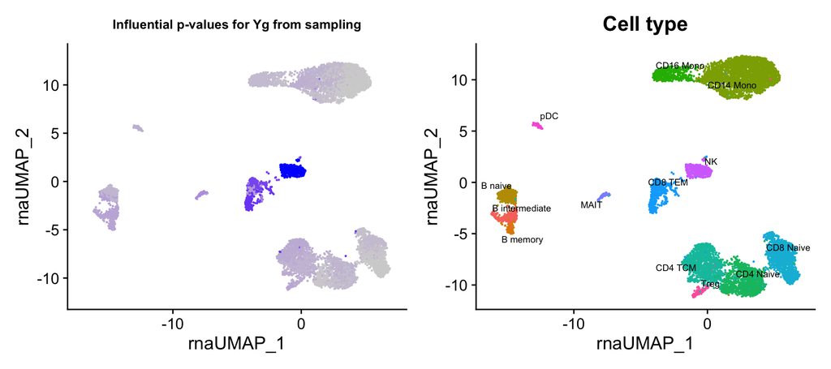

```r
p1=plotFeatureForNeighbor(delta.coeff.pval = delta.coeff.pval,
                            object = pbmc, reduction = reduction, label = FALSE)
p2=DimPlot(pbmc, reduction = reduction, group.by = "celltype",
              label = TRUE, label.size = 2.5, repel = TRUE) + ggtitle("Cell type")
p1+p2 + plot_layout(ncol = 2) & NoLegend()
```